# Historie (júlový turnus)

Zpět na rozcestník zpětné vazby | Tento report we Wordu | Data v CSV

## Hodnocení kurzu

Průměrná známka:

| Blok setkání | Průměrná známka |
| --- | --- |
| A | 1.19 |

### Hodnocení po dnech

A a B jsou bloky (A je 9-10:30, B je 11-12:30)

Známky jsou jako ve škole: 1 je nejlepší, 5 nejhorší

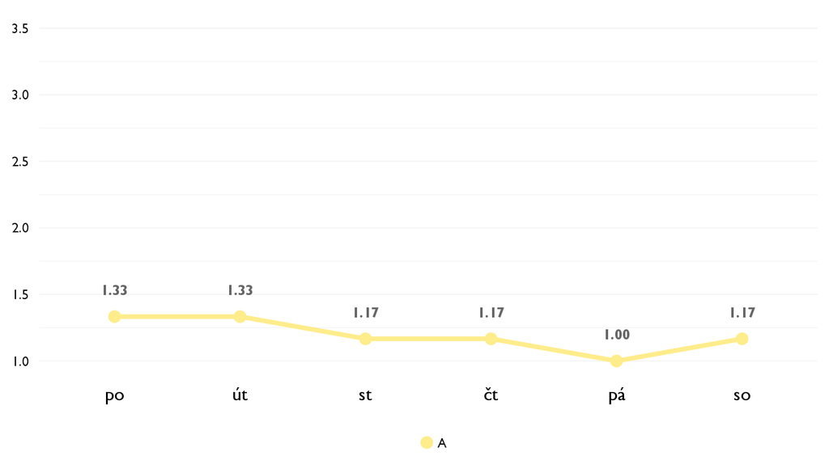

### Co se na kurzu líbilo

- pohľad na to, ako historik musí rozmýšlať
- Veľmi sa mi páčili témy ,ktore sme preberali na tomto kurze a spôsob akým ich nas lektor podal. Naučilo ma to o histórii premýšľať z uplne iného uhli a rozhodne mi to veľa dall do budúceho štúdia.
- Pohlad na fakty a informacie ; obrazky, mapy
- pripomenulo mi to, ze mam byt podozrievava. predtym to bola len fraza, teraz viem aj preco sa ta podozrievavost hodi.
- Nejvíc se mi líbil přístup a vedení kurzu, které še zaměřilo předefším na to naučit nás dívat se na historii z jiných úhlů pohledu, zamýšlet se nad zdroji, pojmy a mnohým dalším. Příjde mi, že rozvíjel mé myšlení nejen v oblasti historie, ale i všeobecně a to hodně oceňuji.
- Rozoberanie histórie nielen na povrchu ale hlavne diskutovanie príčin, zdrojov, uhľov pohľadu a diskurzov.

### Co na kurzu změnit

- Nič
- Nic..
- trochu menej timovzch aktivit
- Nenapadá mě co měnit.
- Na samotnom kurze mi nechýbalo nič konkrétne.

## Hodnocení lektora

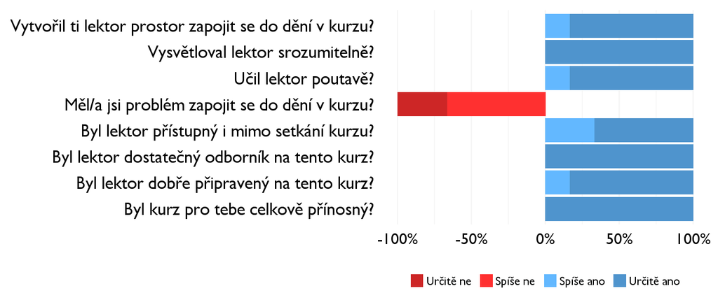

### Komentáře k lektorovi

- Chcela by som vyzdvihnúř snahu o to aby sme sa všetci zapájali do diskusie a to že sa nás pýtal počas vysvetlovania či všetko chápeme.

## Náročnost kurzu

### **Jak hodnotíš náročnost…**

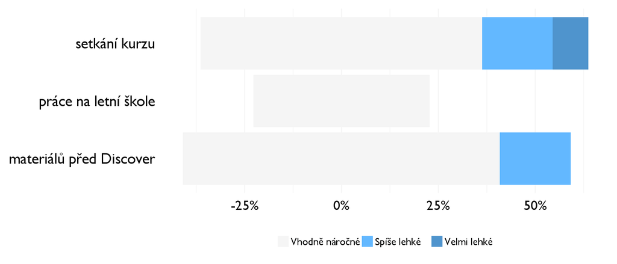

## Didaktika

Na některé otázky jsme se na augustovém turnuse neptali - tam uvidíte nadpis bez grafu.

### Jak lektor učí a měl by to změnit?

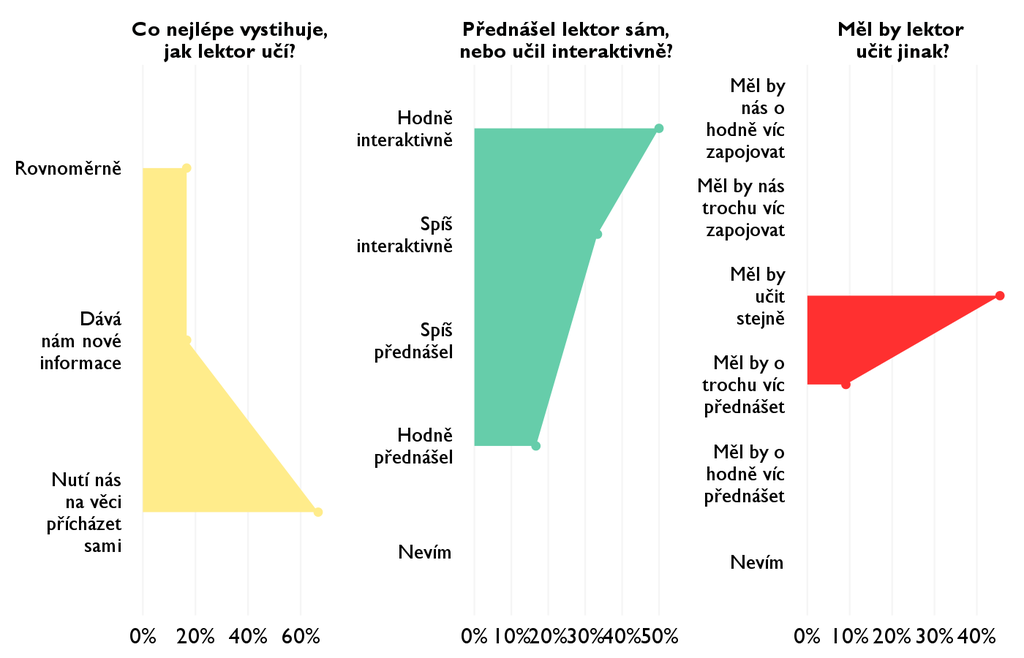

### Jak se studentům nejlépe učí?

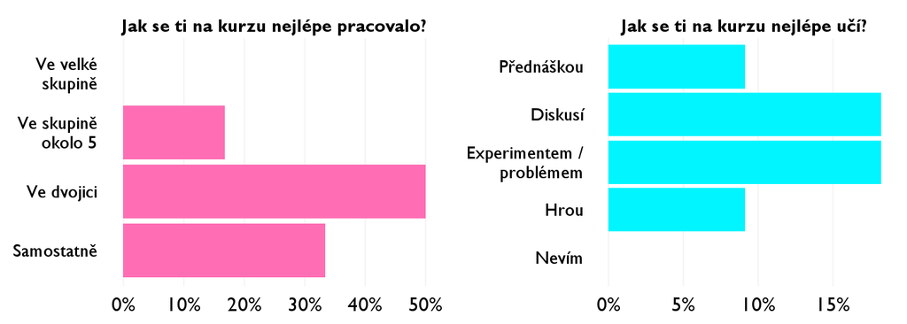

## Ovlivnil tě kurz nějak?

**Pokud ano, jak? Pokud ne, proč ne?**

- ano, zmenil mi zmýšlanie o práci historika
- Ano, kurz urcite ovplyvnil spôsob akým premýšľam a donútil ma uvedomiť si v akých oblastiach by som sa mala zlepšiť.
- Celkovy pohlad na ziskavanie info
- najblizsie budem omnoho viac filtrovat informacie
- V mém myšlení, názorech a pohledech na historii a nejen na ni.
- Budem sa snažiř inak príjmař a vyvodzovat informácie z mne podaných materiálov, už viem že to čo je na povrchu nemusí byř vždy pravda a je potrebné ísř hlbšie.